# Lecture 8 - Hypothesis testing II

Author: Matthew J. Cossley

Last update: 25 April, 2022

## Learning objectives

- Define and understand how to perform a **two-tailed** hypothesis test.
- In the context of **two-tailed hypothesis tests**, define and understand the following:
  - p-values
  - more extreme outcomes*
  - critical value
  - rejection region
  - $1-\alpha\%$ confidence interval
- Be able to perform two-tailed binomial tests, Normal, and t-tests manually (i.e., run through the 5 steps).
- Understand when and how to use `binom.test()` to perform two-tailed binomial tests.
- Understand when and how to use `t.test()` to perform two-tailed t-tests.
- Define, understand, and reason about type I error, type II error, and power.

## Two-tailed tests introduction

- Last lecture, we learned how to perform one-tailed hypothesis tests. The hypothesis framing in those tests was as follows:

$$H_0: \theta = c \\
H_1: \theta < c \\
\text{or} \\
H_0: \theta = c \\
H_1: \theta > c$$

- The hypotheses of a two-tailed test takes the following form:

$$H_0: \theta = c \\
H_1: \theta \neq c \\
H_1: \theta < c \text{ or } \theta > c$$

- As we will see in the following examples, the main difference between one-tailed and two-tailed tests is that the p-value gets contributions from both the lower and the upper tail of the sampling distribution.

## Two-tailed Binomial test

In the binomial test example from last lecture we considered an experiment in which researchers are trying to determine if a particular rat has learned to press one of two levers whenever they are placed inside of an experimental apparatus. Suppose that the experiment contained $n=100$ trials and the number of trials in which the rat pressed the correct lever was $n_{\text{pressed}}=61$.

Did the rat learn or not?

In answering this question, suppose that we are concerned that the rat may have learned to press the wrong lever (perhaps through experimenter error). This puts us into a two-tailed test scenario.

**1. Specify the null and alternative hypotheses ($H_0$ and $H_1$) in terms of a distribution and population parameter.**

$$X \sim binomial(n=100, p) \\
H_0: p = 0.5 \\
H_1: p \neq 0.5$$

**2. Specify the type I error rate – denoted by the symbol $\alpha$ – you are willing to tolerate.**

$$\alpha = 0.05$$

**3. Specify the sample statistic that you will use to estimate the population parameter in step 1 and state how it is distributed under the assumption that $H_0$ is true.**

$$\widehat{p} = \frac{X}{n} \sim binomial(n=100, p=0.5) \\
x \rightarrow \frac{x}{n}\\$$

**4. Obtain a random sample and use it to compute the sample statistic from step 3. Call this value $\widehat{\theta}_{\text{obs}}$**

$$\begin{align}
\widehat{\theta}_{\text{obs}} &= \widehat{p}_{\text{obs}} \\
&= \frac{x_{\text{obs}}}{n} \\
&= \frac{61}{100}
\end{align}$$

**5. If $\widehat{\theta}_{\text{obs}}$ is very unlikely to occur under the assumption that $H_0$ is true, then reject $H_0$. Otherwise, do not reject $H_0$.**

- Below, we compute the critical values and p-values and plot them on the sampling distribution.
- Because this is a two-tailed test, we have critical values above and below the mean.
- Similarly, in two-tailed tests, what counts as *more extreme values* extends in both directions.
- To get the p-value from a two-tailed test, you need to compute one p-value for the probability of getting more extreme results in one direction, and also compute a separate p-value for the probability of getting more extreme results in the other direction.
- In the plot below, I have written `x_obs_lower` and `x_obs_upper` to faciliate thinking about this, but keep in mind that we only acutally observed `x_obs_upper`.
- `x_obs_lower` is obtained from `x_obs_upper` by reflecting it around the mean of the sampling distribution.
- Critical values are obtained by splitting $\alpha$ in half and using one half in the lower tail and one half in the upper tail.

```r
n <- 100
p <- 0.5

xobs <- 61/n
xobs_upper <- xobs
xobs_lower <- -(xobs_upper - 0.5) + 0.5

x_crit_upper <- qbinom(0.05/2, n, p, lower.tail=FALSE) / n
x_crit_lower <- qbinom(0.05/2, n, p, lower.tail=TRUE) / n
```

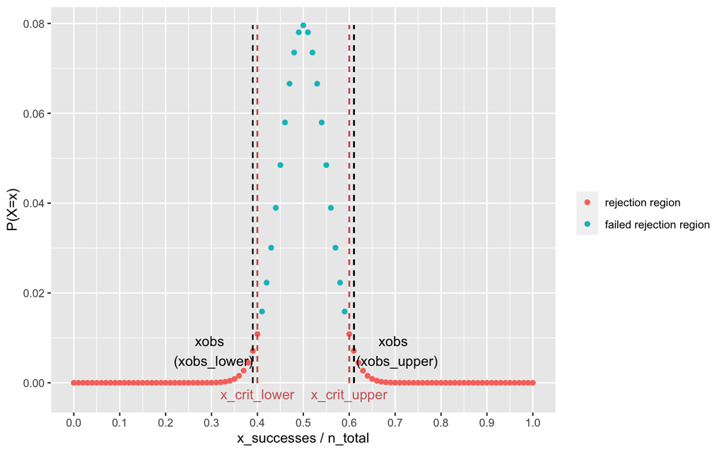

```r
# compute p-value by hand
pval_upper <- pbinom(xobs_upper*n-1, n, p, lower.tail=FALSE)
pval_lower <- pbinom(xobs_lower*n, n, p, lower.tail=TRUE)
pval <- pval_upper + pval_lower
pval
```

```
## [1] 0.0352002
```

```r
# check with binom.test
binom.test(xobs_upper*n, n, p, alternative = "two.sided")
```

```
##
##  Exact binomial test
##
## data:  xobs_upper * n and n
## number of successes = 61, number of trials = 100, p-value = 0.0352
## alternative hypothesis: true probability of success is not equal to 0.5
## 95 percent confidence interval:
##  0.5073145 0.7059896
## sample estimates:
## probability of success
##                   0.61
```

## Two-tailed Normal test

Last lecture we considered an experiment in which a rat is placed into a maze and given the chance to search for a bit of cheese hidden somewhere in the maze. The researchers know that rats without any training whatsoever find the cheese on average in 90 seconds with a standard deviation of 20 seconds. After much training, the researchers are interested in assessing whether or not the animal has learned where the cheese is hidden or on the contrary, if the animal has become frustrated and is taking longer than baseline.

**1. Specify the null and alternative hypotheses ($H_0$ and $H_1$) in terms of a distribution and population parameter.**

$$H_0: \mu = 90 \\
H_1: \mu \neq 90$$

**2. Specify the type I error rate – denoted by the symbol $\alpha$ – you are willing to tolerate.**

$$\alpha = 0.05$$

**3. Specify the sample statistic that you will use to estimate the population parameter in step 1 and state how it is distributed under the assumption that $H_0$ is true.**

$$\widehat{\mu} = \bar{x} \\
\bar{x} \sim \mathcal{N}(\mu_{\bar{x}}, \sigma_{\bar{x}}) \\
\mu_{\bar{x}} = \mu_{x} \\
\sigma_{\bar{x}} = \frac{\sigma_{x}}{\sqrt{n}}$$

**4. Obtain a random sample and use it to compute the sample statistic from step 3. Call this value $\widehat{\theta}_{\text{obs}}$**

The researchers perform 15 trials and measure the time to cheese on each trial. The data are as follows:

```r
xobs <- c(105.25909, 73.47533, 106.59599, 105.44859, 88.29283,
          49.20100, 61.42866, 74.10559, 79.88466, 128.09307,
          95.27187 ,64.01982 ,57.04686 ,74.21077, 74.01570)
xbarobs <- mean(xobs)
```

**5. If $\widehat{\theta}_{\text{obs}}$ is very unlikely to occur under the assumption that $H_0$ is true, then reject $H_0$. Otherwise, do not reject $H_0$.**

```r
n <- 15
mux <-90

sigx <- 20
muxbar <- 90
sigxbar <- sigx / sqrt(n)

xbarobs_upper <- -(xbarobs - mux) + mux
xbarobs_lower <- xbarobs

xbar_crit_upper <- qnorm(0.05/2, muxbar, sigxbar, lower.tail=FALSE)
xbar_crit_lower <- qnorm(0.05/2, muxbar, sigxbar, lower.tail=TRUE)
```

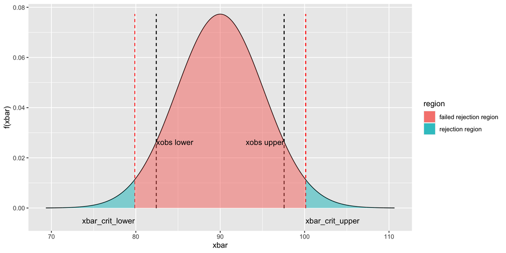

```r
# compute p-value by hand
pval_upper <- pnorm(xbarobs_upper, muxbar, sigxbar, lower.tail=FALSE)
pval_lower <- pnorm(xbarobs_lower, muxbar, sigxbar, lower.tail=TRUE)
pval <- pval_upper + pval_lower
pval
```

```
## [1] 0.1423169
```

## Two-tailed t-test

- t-test arises from the Normal test scenarios in which the sample variance $\sigma_X$ is unknown.

**1. Specify the null and alternative hypotheses ($H_0$ and $H_1$) in terms of a distribution and population parameter.**

$$H_0: \mu = 90 \\
H_1: \mu \neq 90$$

**2. Specify the type I error rate – denoted by the symbol $\alpha$ – you are willing to tolerate.**

$$\alpha = 0.05$$

**3. Specify the sample statistic that you will use to estimate the population parameter in step 1 and state how it is distributed under the assumption that $H_0$ is true.**

$$\widehat{\mu} = \bar{x} \\
\bar{x} \sim \mathcal{N}(\mu_{\bar{x}}, \sigma_{\bar{x}}) \\
\mu_{\bar{x}} = \mu_{x} \\
\sigma_{\bar{x}} = \frac{\sigma_{x}}{\sqrt{n}} \rightarrow
\widehat{\sigma}_{\bar{x}} = \frac{s_{x}}{\sqrt{n}} \\
t = \frac{\bar{x} - \mu_x}{\frac{s_x}{\sqrt{n}}} \sim t(n-1)$$

**4. Obtain a random sample and use it to compute the sample statistic from step 3. Call this value $\widehat{\theta}_{\text{obs}}$**

The researchers perform 15 trials and measure the time to cheese on each trial. The data are as follows:

```r
xobs <- c(105.25909, 73.47533, 106.59599, 105.44859, 88.29283,
          49.20100, 61.42866, 74.10559, 79.88466, 128.09307,
          95.27187 ,64.01982 ,57.04686 ,74.21077, 74.01570)

n <- length(xobs)
xbarobs <- mean(xobs)
sigxbarobs <- sd(xobs) / sqrt(n)

mux <-90
muxbar <- 90

tobs <- (xbarobs - muxbar) / sigxbarobs
```

**5. If $\widehat{\theta}_{\text{obs}}$ is very unlikely to occur under the assumption that $H_0$ is true, then reject $H_0$. Otherwise, do not reject $H_0$.**

```r
tobs_upper <- -tobs
tobs_lower <- tobs

t_crit_upper <- qt(0.05/2, n-1, lower.tail=FALSE)
t_crit_lower <- qt(0.05/2, n-1, lower.tail=TRUE)
```

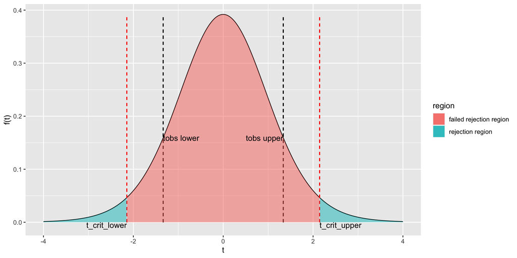

```r
# compute p-value by hand
pval_upper <- pt(tobs_upper, n-1, lower.tail=FALSE)
pval_lower <- pt(tobs_lower, n-1, lower.tail=TRUE)
pval <- pval_upper + pval_lower
pval
```

```
## [1] 0.2024876
```

```r
# check with t.test
t.test(xobs, mu=mux, alternative='two.sided')
```

```
##
##  One Sample t-test
##
## data:  xobs
## t = -1.3372, df = 14, p-value = 0.2025
## alternative hypothesis: true mean is not equal to 90
## 95 percent confidence interval:
##  70.27055 94.57609
## sample estimates:
## mean of x
##  82.42332
```

## Confidence intervals

- Way back in the beginning of the class we covered descriptive statistics, and more recently we have used some of these descriptive statistics as **estimates** of population parameters.
- For example, we have used the sample mean $\bar{x}$ as an estimate of the population mean $\mu_X$.
- This is an example of a **point estimate** of a population parameter, and it represents our single best guess about the true value of the parameter in question.
- An alternative approach to point estimation is to instead try to estimate a range of values in which the true value of the parameter is likely to reside.
- This is called **interval estimation** and it is accomplished by constructing a **confidence interval**.
- To construct a confidence interval for the population mean $\mu_X$ (assuming the population variance $\sigma_X^2$ is known), first compute the sample mean $\bar{x}$.
- Next, the width of the CI is the same as the width of the distribution of sample means required to cover $1-\alpha$ percent of it’s probability. Call this width $w$.
- Then the confidence interval estimate of $\mu_X$ is given by $CI = \left[ \bar{x}-w \text{, } \bar{x}+w \right]$

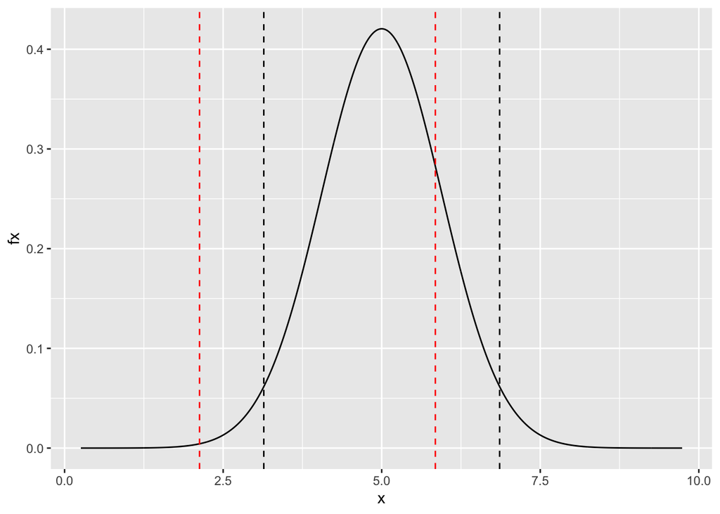

- In the above plot, red vertical lines mark the confidence interval and black vertical lines mark the critical values.
- CI is always centred around the observed value.
- Critical values are always centred around the mean of the null sampling distribution.
- This can all be written concisely as follows:

$$CI_{1-\alpha} = \left[ \bar{x} - \Phi_{\bar{X}}^{-1}(1-\frac{\alpha}{2}),
\text{ }
\bar{x} + \Phi_{\bar{X}}^{-1}(1-\frac{\alpha}{2}) \right]$$

- For example, the 95% confidence interval for the population mean of $X \sim N(\mu_X, \sigma_X)$ is given by:

$$\begin{align}
CI_{1-0.05} &= \left[ \bar{x} - \Phi_{X}^{-1}(1-\frac{0.05}{2}),
\text{ }
\bar{x} + \Phi_{X}^{-1}(1-\frac{0.05}{2}) \right]
\\ \\
CI_{.95} &= \left[ \bar{x} - \Phi_{X}^{-1}(1-0.025),
\text{ }
\bar{x} + \Phi_{X}^{-1}(1-0.025) \right]
\\ \\
&= \left[ \bar{x} - \Phi_{X}^{-1}(0.975),
\text{ }
\bar{x} + \Phi_{X}^{-1}(0.975) \right]
\end{align}$$

- Notice that just like the point estimate $\bar{x}$, a confidence interval is also a random variable, and so changes with every experiment performed.
- We can demonstrate this by repeating the procedure and observing that the obtained confidence intervals are different with each repetition.

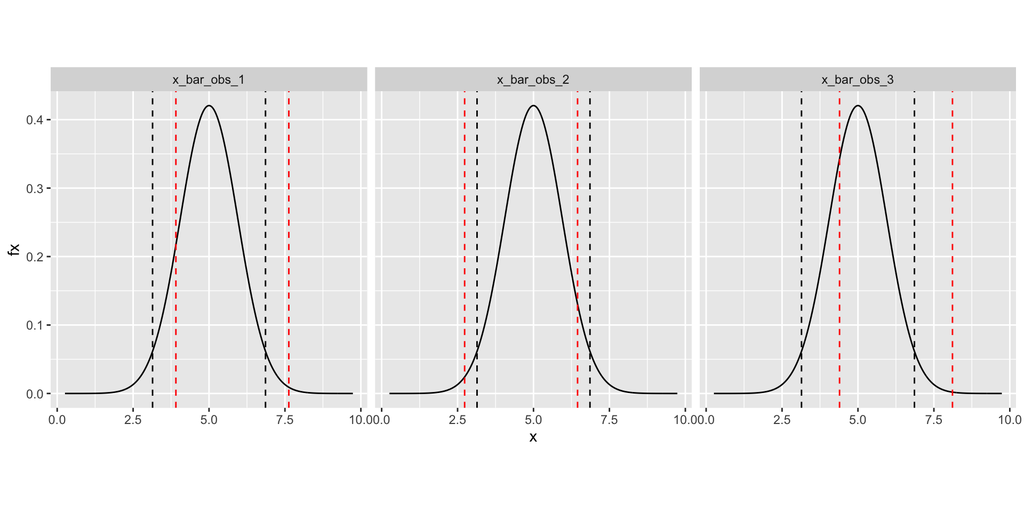